# act_report

## Report: act_report

When all dogs are good dogs we reach a wall when trying to rate such magnificent buddies. But here comes this page that tries to do the impossible and provide us with a number for all the "good boys" out there!

With atleast 113 different dog breeds, there is a wide range of results, from 0/10 scores to 1776/10 (yes, that's the range of numerators, but even the denominators can go from 2 to 170!)

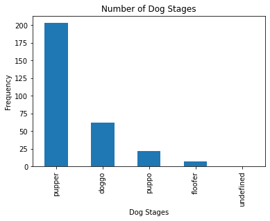

But that's not all, because the juri might be biased! So the audience (people who saw the tweets) also have their voice and the "favorite" button of the tweet as a voting ballot. In this kind of rating system, puppos are generaly the most loved (please don't misunderstand, every one of these dogs is loved!) with an average of 19.924 favorites on their tweets! But on a fun turn of events, the audience has another voting ballot (the retweet!) and the most sharable tweet is the one with a doggo in it, with an average of 6095 retweets!

Of course, tweets with more favorite counts seem to have more retweets too, when we like our "good boys" so much we just want the whole world to see and give them them the love they deserve.

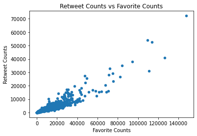

After all, on average, these dogs have a rating of 12/10, so they break the scale of logic on how good they are!